# Synthetic-Control

aaron mamula

6/11/2020

[Synthetic Control Methods for Comparative Case Studies: Estimating the Effect of California's Tobacco Control Program](https://economics.mit.edu/files/11859)

Abadie, A., Diamond, A., Hainmueller, J. (2014). Comparative Politics and the Synthetic Control Method. American Journal of Political Science Forthcoming 2014.

Synthetic : An R Package for Synthetic Control Methods in Comparative Case Studies. Journal of Statistical Software 42 (13) 1–17.

Abadie A, Diamond A, Hainmueller J (2010). Synthetic Control Methods for Comparative Case Studies: Estimating the Effect of California’s Tobacco Control Program. Journal of the American Statistical Association 105 (490) 493–505.

[Abadie, A. and Gardeazabal, J. (2003) Economic Costs of Conflict: A Case Study of the Basque Country American Economic Review 93 (1) 113–132](https://economics.mit.edu/files/11870).

[Impact of Drought on Crime in California](https://journals.plos.org/plosone/article?id=10.1371/journal.pone.0185629)

## Intro

Synthetic Control is an inferential methodology for comparative cases studies. The technique has some high-level conceptual similarities to Difference-in-Differences estimators. A key difference between the two is that D-i-D generally attempts to uncover some "treatment effect" by matching treated units to similar untreated units. The canonical example is Card and Krueger, 1994 (Minimum wages and employment: A case study of the New Jersey and Pennsylvania fast food industries, *American Economic Review*). In contrast to D-i-D, Synthetic Control attempts to empirically construct a single comparable non-treated unit (using a linear combination of control units) in order to assess the credible counter factual.

## Methods

In this exercise I'm following along with the sample code provided in [Synthetic : An R Package for Synthetic Control Methods in Comparative Case Studies. Journal of Statistical Software 42 (13) 1–17](https://www.jstatsoft.org/article/view/v042i13). Most of the code in this workbook come directly out of that Journal Article.

I have provided a high-level view of some of the math behind Synthetic Control. Since I suspect this will be the least interesting part of the Vignette, I have tucked the math-y stuff at the end.

```r
library(Synth)
library(dplyr)
```

```r
library(ggplot2)
library(ggthemes)
library(data.table)
library(tidyr)
data(basque)
head(basque)
```

```
##   regionno     regionname year   gdpcap sec.agriculture sec.energy sec.industry
## 1        1 Spain (Espana) 1955 2.354542              NA         NA           NA
## 2        1 Spain (Espana) 1956 2.480149              NA         NA           NA
## 3        1 Spain (Espana) 1957 2.603613              NA         NA           NA
## 4        1 Spain (Espana) 1958 2.637104              NA         NA           NA
## 5        1 Spain (Espana) 1959 2.669880              NA         NA           NA
## 6        1 Spain (Espana) 1960 2.869966              NA         NA           NA
##   sec.construction sec.services.venta sec.services.nonventa school.illit
## 1               NA                 NA                    NA           NA
## 2               NA                 NA                    NA           NA
## 3               NA                 NA                    NA           NA
## 4               NA                 NA                    NA           NA
## 5               NA                 NA                    NA           NA
## 6               NA                 NA                    NA           NA
##   school.prim school.med school.high school.post.high popdens invest
## 1          NA         NA          NA               NA      NA     NA
## 2          NA         NA          NA               NA      NA     NA
## 3          NA         NA          NA               NA      NA     NA
## 4          NA         NA          NA               NA      NA     NA
## 5          NA         NA          NA               NA      NA     NA
## 6          NA         NA          NA               NA      NA     NA
```

## Data

Operationally, Synthetic Control organizes matricies according to cross-sectional units, time-periods, predictors, and outcome variables. Let's familiarize ourselves with the basic elements of the data:

```r
unique(basque$regionname)
```

```
##  [1] "Spain (Espana)"               "Andalucia"
##  [3] "Aragon"                       "Principado De Asturias"
##  [5] "Baleares (Islas)"             "Canarias"
##  [7] "Cantabria"                    "Castilla Y Leon"
##  [9] "Castilla-La Mancha"           "Cataluna"
## [11] "Comunidad Valenciana"         "Extremadura"
## [13] "Galicia"                      "Madrid (Comunidad De)"
## [15] "Murcia (Region de)"           "Navarra (Comunidad Foral De)"
## [17] "Basque Country (Pais Vasco)"  "Rioja (La)"
```

So we have 18 unique regions. Measured over how many time-periods?

```r
unique(basque$year)
```

```
##  [1] 1955 1956 1957 1958 1959 1960 1961 1962 1963 1964 1965 1966 1967 1968 1969
## [16] 1970 1971 1972 1973 1974 1975 1976 1977 1978 1979 1980 1981 1982 1983 1984
## [31] 1985 1986 1987 1988 1989 1990 1991 1992 1993 1994 1995 1996 1997
```

## Data Summaries

### Outcome and Predictor Variables

I'm not sure how informative this part will be but it's probably good practice to know something about how the data are distributed.

The Basque Terrorism Study uses Per Capita GDP (`gdpcap`) as the outcome variable with the following predictor variables:

- (gross total investment)/GDP (`invest`)
- share of working age population that was illiterate, 1964-1969 avg. (`school.illit`)
- share of working age population with up to primary school education, 1964-1969 avg. (`school.prim`)
- share of working age population with some high school, 1964-1969 avg. (`school.med`)
- share of working age population with high school education, 1964-1969 avg. (`school.high`)
- share of working age populaiton with more than a high school education, 1964-1969 avg. (`school.post.high`)
- Sector share: agricultural, forestry, and fishing (`sec.agriculture.1961.1969`)
- Sector share: energy and water (`sec.energy.1961.1969`)
- Sector share: industrial (`sec.industry.1961.1969`)
- Sector share: construction and engineering (`sec.construction.1961.1969`)
- Sector share: marketable services (`sec.services.venta.1961.1969`)
- Sector share: non-marketable services (`sec.services.nonventa.1961.1969`)
- Real GDP per capita, 1960-1969 avg. (`gdpcap`)
- Population Density in 1969 (`popden`)

Sector shares are calculated as the share of total production and measured as the 1961-1969 average.

### Summary Stats

This part does not appear in the [JSTATSOFT](https://www.jstatsoft.org/article/view/v042i13) vignette but I wanted to put it in mostly to feel like I'm contributing some value-added.

Let's vizualize the sector production shares for the different regions:

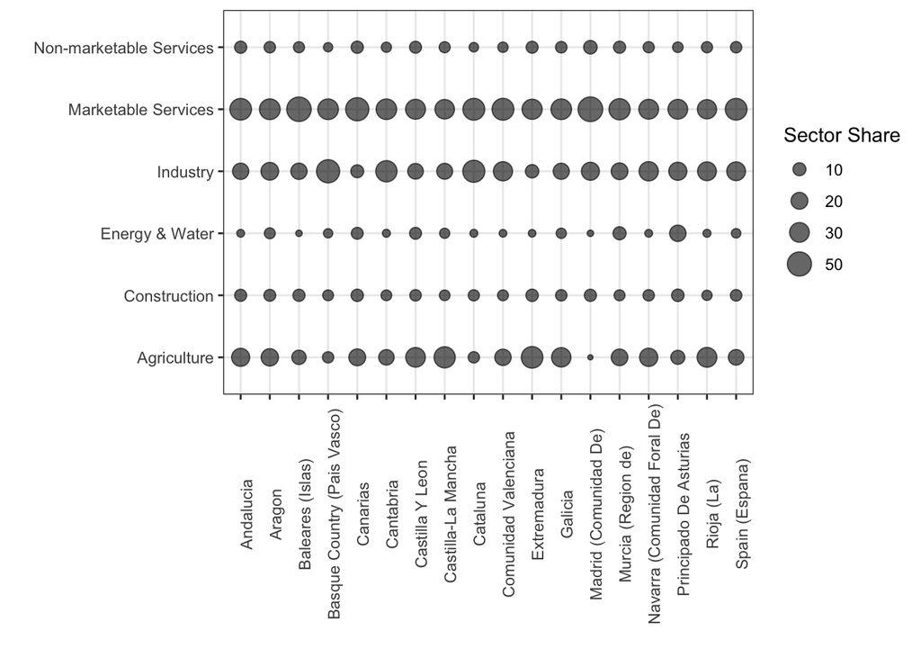

```r
# squish the data into long format
plot.df <- basque %>% select(year,regionname,sec.agriculture,sec.energy,sec.industry,sec.construction,sec.services.nonventa,sec.services.venta) %>% filter(year >= 1961 & year  <= 1969) %>%
          group_by(regionname) %>%
     pivot_longer(cols=starts_with("sec"),names_to="sector",values_to="count")

# take the 1961 - 1969 avg. for each sector
plot.df <- plot.df %>% group_by(regionname,sector) %>%
               summarise(mean=mean(count,na.rm=T))
# make the sector name more informative
plot.df <- plot.df %>% mutate(new.name=ifelse(sector=="sec.services.venta","Marketable Services",
                                      ifelse(sector=="sec.services.nonventa","Non-marketable Services",
                                      ifelse(sector=="sec.industry","Industry",
                                      ifelse(sector=="sec.energy","Energy & Water",
                                      ifelse(sector=="sec.construction","Construction","Agriculture"))))))

ggplot(plot.df, aes(x=regionname,y=new.name,size=mean)) + geom_point(alpha=0.6) +
  theme_bw() +
  scale_size_continuous(breaks=c(0,10,20,30,50),name="Sector Share") +
  theme(axis.text.x=element_text(angle=90)) +
  xlab("") + ylab("")
```

Now let's look at the educational variables:

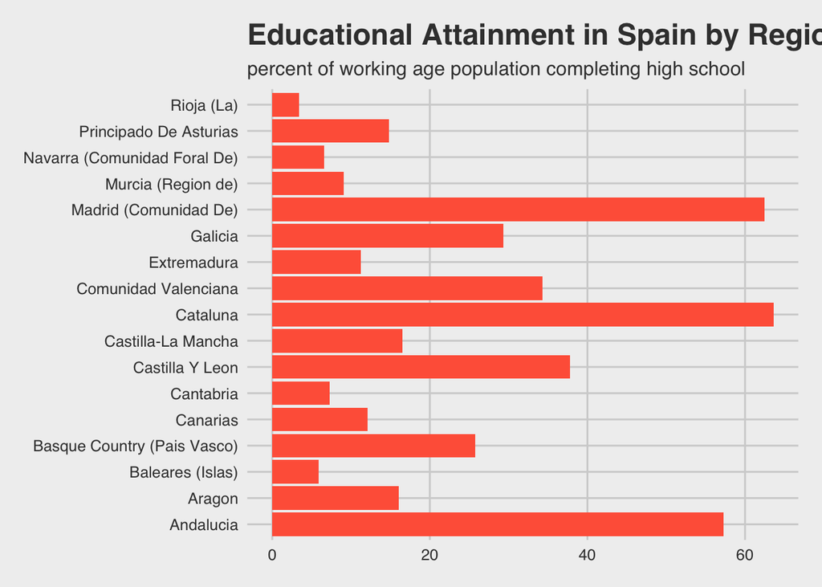

```r
#maybe just restrict attention to high school attainment
plot.df <- basque %>% filter(year >= 1964 & year <= 1969) %>%
            select(regionname, year, school.high) %>% group_by(regionname) %>%
             summarise(school.high=mean(school.high,na.rm=T))
# remove the "all of Spain" region
ggplot(subset(plot.df,regionname!="Spain (Espana)"),aes(x=regionname,y=school.high)) +
  geom_bar(stat='identity',fill='tomato') +
  coord_flip() + theme_fivethirtyeight() +
  xlab("") + ylab("") +
  ggtitle(label = "Educational Attainment in Spain by Region",
              subtitle = "percent of working age population completing high school")
```

## Synthetic Control with "Synth"

The machinery of Synthetic Control uses optimization to find a set of weights that creates a unit which is as similar as possible to the treated unit in the pre-treatment period.

Here "similarity" is influenced by:

1. The predictors we include in the model. This refers to the `gdpcap`, `popdens`, `school.illit`, etc.
2. The cross-sectional units we include in the universe of possible "controls".

Again, the meat of Synthetic Control is to find an optimal weighting vector $W=[w_1,...w_N]$ which will be applied to the predictor values of the control units. The following matricies are critical to the implementation:

- $X_1$, a (k X 1) vector predictor values for the treated unit
- $X_0$, a (k X J) matrix of predictor values for the control units
- $Z_1$, a ($T_P$ X 1) vector of outcome variables for the treated unit in the pre-treatment period
- $Z_0$, a ($T_P$ X J) matrix of outcome variables for the control units in the pre-treatment period

Here the general notation $T_P$ is used to define the pre-treatment period because the `synth` user can define which pre-treatment time periods they wish to use to construct the sythetic control.

The objects $X_1$, $X_0$, $Z_0$, $Z_1$ can be supplied individually to different methods within in the `synth` library. But that would make things harder than they need to be because the `synth` method `dataprep()` will prepare the synthetic control data for you:

```r
dataprep.out <- dataprep(
 foo = basque,
 predictors = c("school.illit", "school.prim", "school.med",
 "school.high", "school.post.high", "invest"),
 predictors.op = "mean",
 time.predictors.prior = 1964:1969,
 special.predictors = list(
 list("gdpcap", 1960:1969 , "mean"),
 list("sec.agriculture", seq(1961, 1969, 2), "mean"),
 list("sec.energy", seq(1961, 1969, 2), "mean"),
 list("sec.industry", seq(1961, 1969, 2), "mean"),
 list("sec.construction", seq(1961, 1969, 2), "mean"),
 list("sec.services.venta", seq(1961, 1969, 2), "mean"),
 list("sec.services.nonventa", seq(1961, 1969, 2), "mean"),
 list("popdens", 1969, "mean")),
 dependent = "gdpcap",
 unit.variable = "regionno",
 unit.names.variable = "regionname",
 time.variable = "year",
 treatment.identifier = 17,
 controls.identifier = c(2:16, 18),
 time.optimize.ssr = 1960:1969,
 time.plot = 1955:1997)
```

Something important to note here is that the [JSTATSOFT reference](https://www.jstatsoft.org/article/view/v042i13) says that X1 should be (13 X 1), X0 (13 X 16), Z1 (10 X 1), and Z0 (10 X 13). I'm reasonably sure these are just typos because the ouput displayed in the article (p.8 for reference) clearly has 14 predictors.

## Some Math

Let:

- $Y_{it}^N$ be the outcome for state $i$ in the absence of the policy
- $T^0$ is the time-period of intervention such that $t \in (1,...,T^0)$ is the pre-treatment period
- $Y_{it}^I$ is the outcome for state $i$ if the state were exposed to the policy intervention
- it is assumed that the treatment has no effect before implementation so $Y_{it}^N=Y_{it}^I$ for $t \in (1,...T^0)$

The effect of the intervention is $Y_{it}^I-Y_{it}^N=\alpha_{it}$.